# R Project 2 SDS 322E

Amal Babu, Ani Thakur

5/11/2022

## Connect to Database

```r
connection <- dbConnect(RSQLite::SQLite(), dbname="database.sqlite")
```

## Gathering Datasets

```r
soccer_stats <- tbl(connection, 'Player_Attributes')

player_pos <- read.csv('Player Stats 2015-16.csv')%>%
  select(c('Player', 'Position', 'Appearances'))

player_id <- tbl(connection, 'Player')%>%
  select(c('player_name', 'player_fifa_api_id'))
```

## Merging Datasets by Player ID

```r
soccer <- left_join(soccer_stats, player_id, by = c('player_fifa_api_id'))
soccer <- left_join(soccer, player_pos, by=c('player_name'='Player'), copy=TRUE)
```

## Data Cleaning/Tidying

```r
# select important attributes
soccer <- soccer %>%
  select(c('crossing', 'finishing', 'dribbling', 'sprint_speed', 'stamina', 'strength',
           'aggression', 'vision', 'marking', 'standing_tackle', 'player_name', 'Position', 'Appearances'))
#save as data frame
soccer <- as.data.frame(soccer)
head(soccer)
```

```
##   crossing finishing dribbling sprint_speed stamina strength aggression vision
## 1       49        44        51           64      54       76         71     54
## 2       49        44        51           64      54       76         71     54
## 3       49        44        51           64      54       76         63     54
## 4       48        43        50           64      54       76         62     53
## 5       48        43        50           64      54       76         62     53
## 6       80        53        73           78      79       56         68     66
##   marking standing_tackle        player_name Position Appearances
## 1      65              69 Aaron Appindangoye     <NA>          NA
## 2      65              69 Aaron Appindangoye     <NA>          NA
## 3      65              66 Aaron Appindangoye     <NA>          NA
## 4      62              63 Aaron Appindangoye     <NA>          NA
## 5      62              63 Aaron Appindangoye     <NA>          NA
## 6      76              75    Aaron Cresswell Defender          37
```

```r
# convert integer rows to numeric, drop NA's
soccer <- soccer %>%
  mutate(across(.cols=where(is.integer), .fns = as.numeric))%>%
  drop_na()


# players have multiple entries b/c fifa updates rankings: keep only one ranking per player,
# the first ranking
soccer <- soccer %>%
  group_by(player_name)%>%
  filter(row_number() == 1)%>%
  select(-Appearances)

# create smaller dataset to reduce data points
small_soccer <- soccer %>% ungroup %>% sample_frac(0.2)

#check how many unique categories there are
unique(soccer$Position)
```

```
## [1] "Defender"   "Midfielder" "Goalkeeper" "Forward"
```

## Exploratory Data Analysis

We look at relationships between the main variables in our soccer dataset by looking at a correlation matrix as well as univariate/bivariate graphs. The visualizations show that player’s “marking” ability is very highly correlated with a player’s standing tackle ability. We also find high correlation between a player’s “dribbling” and “crossing,” “dribbling” and “finishing,” and a player’s “standing tackle” and “aggression” abilities. We find a low degree of correlation between “vision” and “marking” as well as “finishing” and “strength.” The Pairs Panels further shows that most variables follow a normal distribution,though skewed, except the “marking” and “standing tackle” variables, which follow a u-shaped distribution.

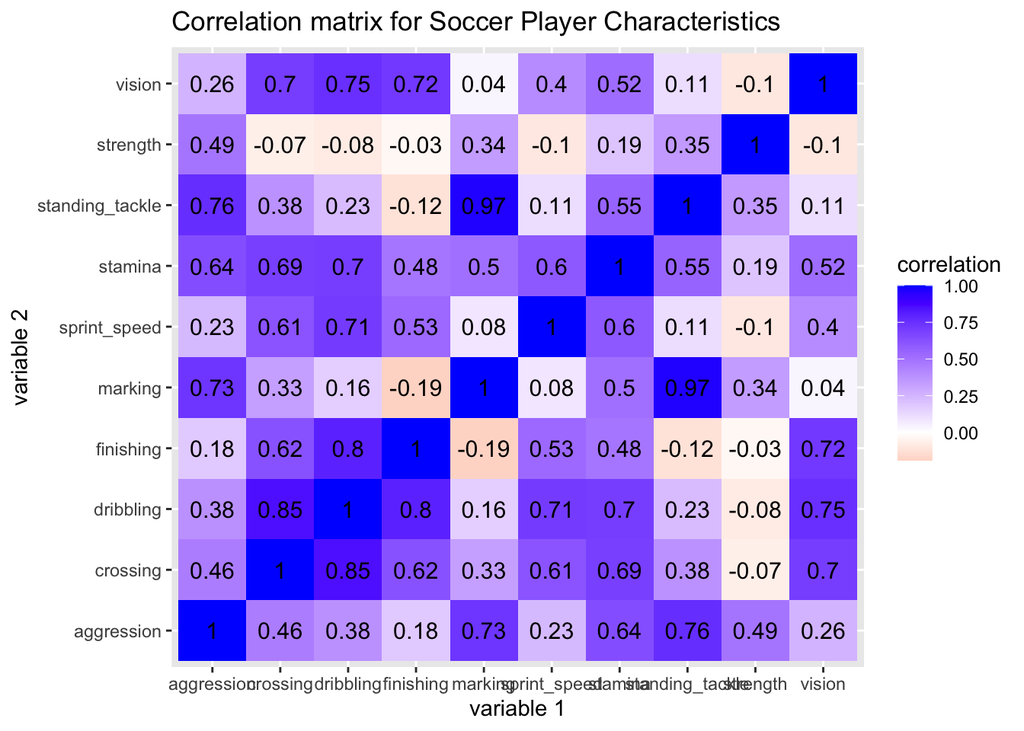

```r
# Correlation Matrix
soccer2 <- soccer %>%
  select_if(is.numeric) %>%
  ungroup()
soccer2 <- soccer2[-c(1)]
cor(soccer2, use = "pairwise.complete.obs") %>%
  as.data.frame %>%
  rownames_to_column %>%
  pivot_longer(-1, names_to = "other_var", values_to = "correlation") %>%
  ggplot(aes(rowname, other_var, fill = correlation)) +
  geom_tile() +
  scale_fill_gradient2(low="red",mid="white",high="blue") +
  geom_text(aes(label = round(correlation,2)), color = "black", size = 4) +
  labs(title = "Correlation matrix for Soccer Player Characteristics", x = "variable 1", y = "variable 2")
```

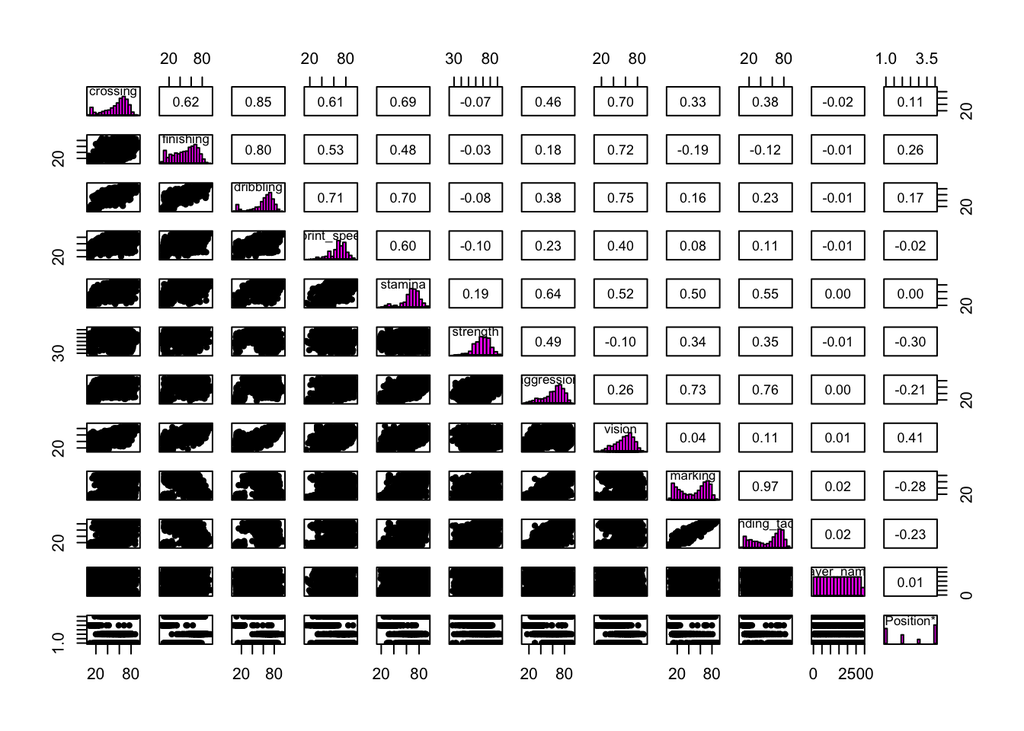

```r
## Univariate/Bivariate Graphs
# install.packages(psych)
library(psych)
pairs.panels(soccer,
             method = "pearson",
             hist.col = "magenta",
             smooth = FALSE, density = FALSE, ellipses = FALSE)
```

## Setting up the Clustering Initially we set up pam for the small_soccer dataset. However, we found that including Midfielders was a problem, as midfielders have attributes of both defenders and attackers, and are this hard to classify.

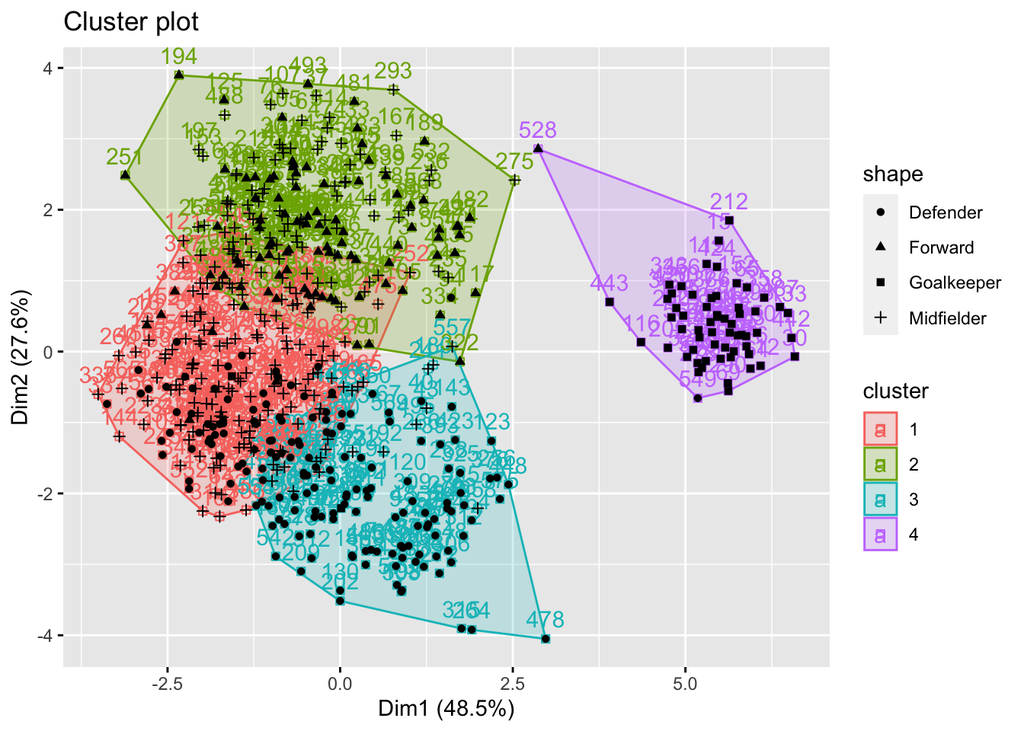

```r
#PAM clustering
pam_results <- small_soccer%>%
  ungroup()%>%
  select_if(is.numeric)%>%
  scale()%>%
  pam(k=4)

fviz_cluster(pam_results, data=small_soccer, shape = 0) +
  geom_point(aes(shape=small_soccer$Position))+
  guides(shape = guide_legend(title = 'shape'))
```

```r
#get rid of midfielders: new dataset
small_soccer_no_mid <- small_soccer %>%
  filter(Position != 'Midfielder')
```